# Mean and SE in outcome

# вероятность успеха 0,5, очень большая выборка (1000 человек), 1000 повторений

## Модель пациента - исследование исхода

## Характеристики исхода

```r
true_mean <- p_true # Истинное среднее (математическое ожидание)

print(true_mean)
```

```
## [1] 0.5
```

```r
variance <- p_true * (1 - p_true) # Дисперсия

print(variance)
```

```
## [1] 0.25
```

```r
standard_deviation <- sqrt(variance)

print(standard_deviation)
```

```
## [1] 0.5
```

## Однократная оценка по выборке

```r
n_patients <- 1000 # Количество пациентов

my_group_outcome_upd <- round(rbinom(n_patients, 1, p_true))

print(my_group_outcome_upd)
```

[output not shown]

```r
sample_mean <- mean(my_group_outcome_upd)

print(sample_mean)
```

```
## [1] 0.495
```

## Набираем статистику

```r
n_patients <- 1000 # Количество добровольцев

n_repeats <- 1000 # Количество повторений эксперимента

df_all_repeats <- data.frame(
  n_exp = rep(1:n_repeats, each = n_patients),
  ID =  rep(1:n_patients, n_repeats),
  outcome_upd = round(rbinom(n_repeats*n_patients, 1, p_true))
)
```

## Оценка среднего в каждом эксперименте

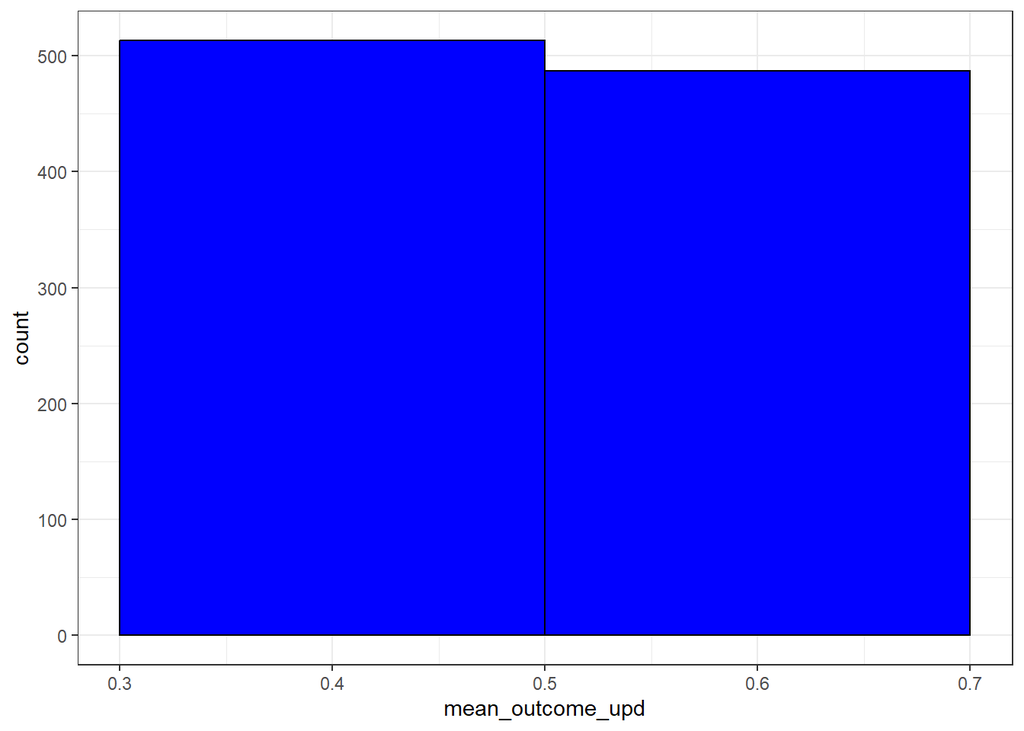

```r
df_sample_mean <- df_all_repeats %>%
  group_by(n_exp) %>%
  dplyr::summarise(mean_outcome_upd = mean(outcome_upd)) %>%
  ungroup()

ggplot(df_sample_mean, aes(x = mean_outcome_upd)) +
  geom_histogram(color = 'black', fill = 'blue', binwidth = 0.2) +
  theme_bw()
```

## Количественные и качественные итоги

```r
error <- sqrt( mean((df_sample_mean$mean_outcome_upd-true_mean)^2) )
print(error)
```

```
## [1] 0.01624146
```

# Истинная вероятность успеха 0,9, очень малая выборка (3 человека), 1000 повторений

## Модель пациента - исследование исхода

## Характеристики исхода

```r
true_mean <- p_true # Истинное среднее (математическое ожидание)

print(true_mean)
```

```
## [1] 0.9
```

```r
variance <- p_true * (1 - p_true) # Дисперсия

print(variance)
```

```
## [1] 0.09
```

```r
standard_deviation <- sqrt(variance)

print(standard_deviation)
```

```
## [1] 0.3
```

## Однократная оценка по выборке

```r
n_patients <- 3 # Количество пациентов

my_group_outcome_upd <- round(rbinom(n_patients, 1, p_true))

print(my_group_outcome_upd)
```

```
## [1] 1 1 1
```

```r
sample_mean <- mean(my_group_outcome_upd)

print(sample_mean)
```

```
## [1] 1
```

## Набираем статистику

```r
n_patients <- 3 # Количество добровольцев

n_repeats <- 1000 # Количество повторений эксперимента

df_all_repeats <- data.frame(
  n_exp = rep(1:n_repeats, each = n_patients),
  ID =  rep(1:n_patients, n_repeats),
  outcome_upd = round(rbinom(n_repeats*n_patients, 1, p_true))
)
```

## Оценка среднего в каждом эксперименте

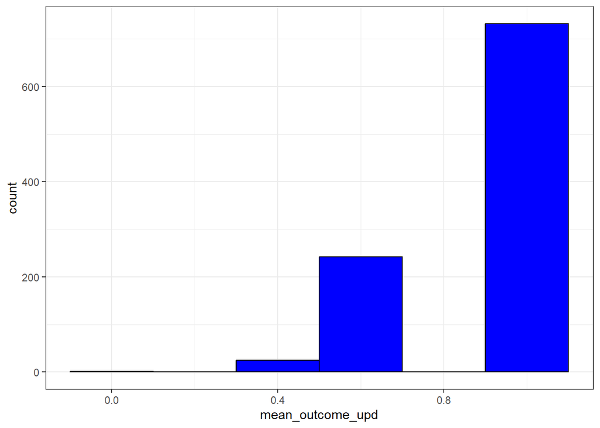

```r
df_sample_mean <- df_all_repeats %>%
  group_by(n_exp) %>%
  dplyr::summarise(mean_outcome_upd = mean(outcome_upd)) %>%
  ungroup()

ggplot(df_sample_mean, aes(x = mean_outcome_upd)) +
  geom_histogram(color = 'black', fill = 'blue', binwidth = 0.2) +
  theme_bw()
```

## Количественные и качественные итоги

```r
error <- sqrt( mean((df_sample_mean$mean_outcome_upd-true_mean)^2) )
print(error)
```

```
## [1] 0.1712698
```

# истинная вероятность успеха 0,9, малая выборка (10 человек), 1000 повторений

## Модель пациента - исследование исхода

## Характеристики исхода

```r
true_mean <- p_true # Истинное среднее (математическое ожидание)

print(true_mean)
```

```
## [1] 0.9
```

```r
variance <- p_true * (1 - p_true) # Дисперсия

print(variance)
```

```
## [1] 0.09
```

```r
standard_deviation <- sqrt(variance)

print(standard_deviation)
```

```
## [1] 0.3
```

## Однократная оценка по выборке

```r
n_patients <- 10 # Количество пациентов

my_group_outcome_upd <- round(rbinom(n_patients, 1, p_true))

print(my_group_outcome_upd)
```

```
##  [1] 1 1 1 1 1 1 1 0 1 1
```

```r
sample_mean <- mean(my_group_outcome_upd)

print(sample_mean)
```

```
## [1] 0.9
```

## Набираем статистику

```r
n_patients <- 10 # Количество добровольцев

n_repeats <- 1000 # Количество повторений эксперимента

df_all_repeats <- data.frame(
  n_exp = rep(1:n_repeats, each = n_patients),
  ID =  rep(1:n_patients, n_repeats),
  outcome_upd = round(rbinom(n_repeats*n_patients, 1, p_true))
)
```

## Оценка среднего в каждом эксперименте

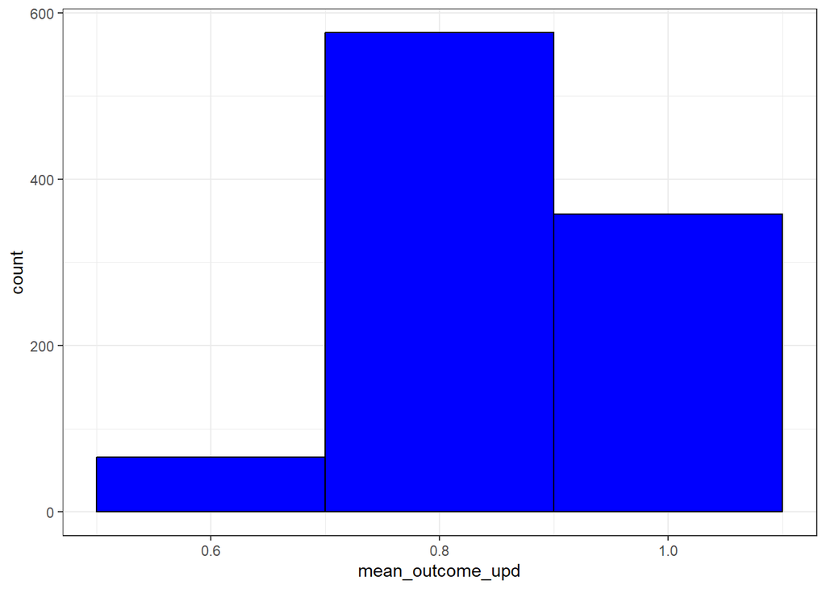

```r
df_sample_mean <- df_all_repeats %>%
  group_by(n_exp) %>%
  dplyr::summarise(mean_outcome_upd = mean(outcome_upd)) %>%
  ungroup()

ggplot(df_sample_mean, aes(x = mean_outcome_upd)) +
  geom_histogram(color = 'black', fill = 'blue', binwidth = 0.2) +
  theme_bw()
```

## Количественные и качественные итоги

```r
error <- sqrt( mean((df_sample_mean$mean_outcome_upd-true_mean)^2) )
print(error)
```

```
## [1] 0.0929516
```

# истинная вероятность успеха 0,9, средняя выборка (50 человек), 1000 повторений

## Модель пациента - исследование исхода

## Характеристики исхода

```r
true_mean <- p_true # Истинное среднее (математическое ожидание)

print(true_mean)
```

```
## [1] 0.9
```

```r
variance <- p_true * (1 - p_true) # Дисперсия

print(variance)
```

```
## [1] 0.09
```

```r
standard_deviation <- sqrt(variance)

print(standard_deviation)
```

```
## [1] 0.3
```

## Однократная оценка по выборке

```r
n_patients <- 50 # Количество пациентов

my_group_outcome_upd <- round(rbinom(n_patients, 1, p_true))

print(my_group_outcome_upd)
```

```
##  [1] 1 1 1 1 1 1 1 1 1 1 1 1 1 1 1 1 1 1 1 1 1 1 1 1 1 1 1 0 1 1 1 1 1 0 1 1 1 1
## [39] 1 1 1 0 1 1 1 1 1 1 1 1
```

```r
sample_mean <- mean(my_group_outcome_upd)

print(sample_mean)
```

```
## [1] 0.94
```

## Набираем статистику

```r
n_patients <- 50 # Количество добровольцев

n_repeats <- 1000 # Количество повторений эксперимента

df_all_repeats <- data.frame(
  n_exp = rep(1:n_repeats, each = n_patients),
  ID =  rep(1:n_patients, n_repeats),
  outcome_upd = round(rbinom(n_repeats*n_patients, 1, p_true))
)
```

## Оценка среднего в каждом эксперименте

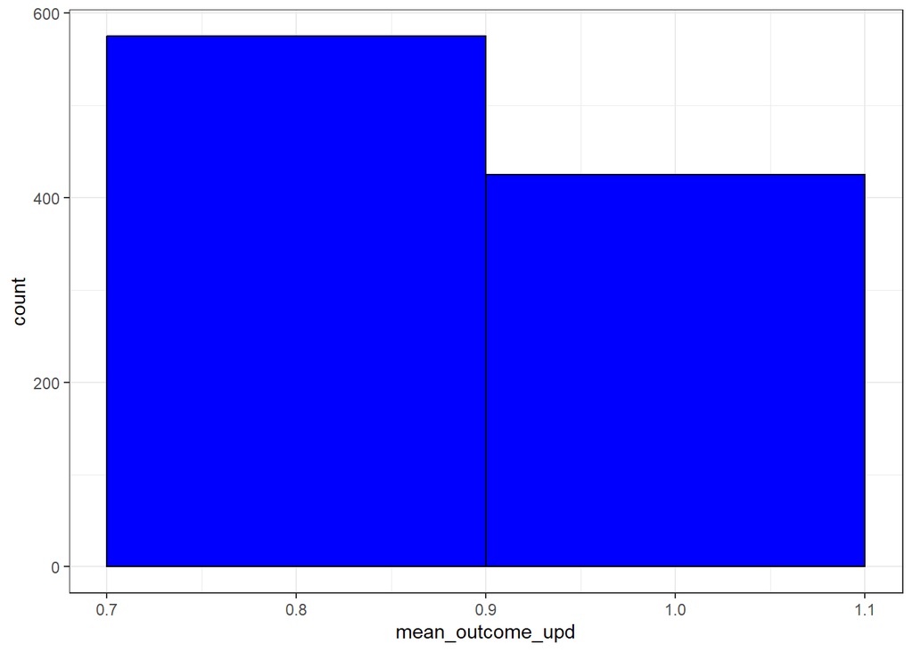

```r
df_sample_mean <- df_all_repeats %>%
  group_by(n_exp) %>%
  dplyr::summarise(mean_outcome_upd = mean(outcome_upd)) %>%
  ungroup()

ggplot(df_sample_mean, aes(x = mean_outcome_upd)) +
  geom_histogram(color = 'black', fill = 'blue', binwidth = 0.2) +
  theme_bw()
```

## Количественные и качественные итоги

```r
error <- sqrt( mean((df_sample_mean$mean_outcome_upd-true_mean)^2) )
print(error)
```

```
## [1] 0.04253939
```

# истинная вероятность успеха 0,9, большая выборка (500 человек), 1000 повторений

## Модель пациента - исследование исхода

## Характеристики исхода

```r
true_mean <- p_true # Истинное среднее (математическое ожидание)

print(true_mean)
```

```
## [1] 0.9
```

```r
variance <- p_true * (1 - p_true) # Дисперсия

print(variance)
```

```
## [1] 0.09
```

```r
standard_deviation <- sqrt(variance)

print(standard_deviation)
```

```
## [1] 0.3
```

## Однократная оценка по выборке

```r
n_patients <- 500 # Количество пациентов

my_group_outcome_upd <- round(rbinom(n_patients, 1, p_true))

print(my_group_outcome_upd)
```

[output not shown]

```r
sample_mean <- mean(my_group_outcome_upd)

print(sample_mean)
```

```
## [1] 0.914
```

## Набираем статистику

```r
n_patients <- 500 # Количество добровольцев

n_repeats <- 1000 # Количество повторений эксперимента

df_all_repeats <- data.frame(
  n_exp = rep(1:n_repeats, each = n_patients),
  ID =  rep(1:n_patients, n_repeats),
  outcome_upd = round(rbinom(n_repeats*n_patients, 1, p_true))
)
```

## Оценка среднего в каждом эксперименте

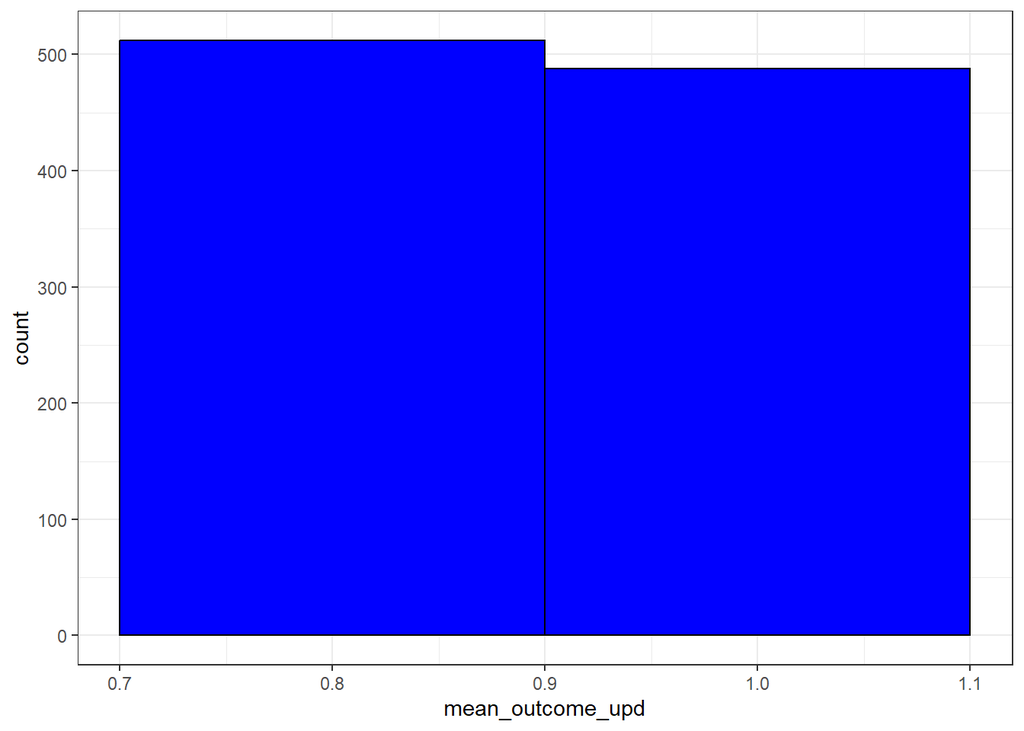

```r
df_sample_mean <- df_all_repeats %>%
  group_by(n_exp) %>%
  dplyr::summarise(mean_outcome_upd = mean(outcome_upd)) %>%
  ungroup()

ggplot(df_sample_mean, aes(x = mean_outcome_upd)) +
  geom_histogram(color = 'black', fill = 'blue', binwidth = 0.2) +
  theme_bw()
```

## Количественные и качественные итоги

```r
error <- sqrt( mean((df_sample_mean$mean_outcome_upd-true_mean)^2) )
print(error)
```

```
## [1] 0.01325911
```

# вероятность успеха 0,9, очень большая выборка (1000 человек), 1000 повторений

## Модель пациента - исследование исхода

## Характеристики исхода

```r
true_mean <- p_true # Истинное среднее (математическое ожидание)

print(true_mean)
```

```
## [1] 0.9
```

```r
variance <- p_true * (1 - p_true) # Дисперсия

print(variance)
```

```
## [1] 0.09
```

```r
standard_deviation <- sqrt(variance)

print(standard_deviation)
```

```
## [1] 0.3
```

## Однократная оценка по выборке

```r
n_patients <- 1000 # Количество пациентов

my_group_outcome_upd <- round(rbinom(n_patients, 1, p_true))

print(my_group_outcome_upd)
```

[output not shown]

```r
sample_mean <- mean(my_group_outcome_upd)

print(sample_mean)
```

```
## [1] 0.913
```

## Набираем статистику

```r
n_patients <- 1000 # Количество добровольцев

n_repeats <- 1000 # Количество повторений эксперимента

df_all_repeats <- data.frame(
  n_exp = rep(1:n_repeats, each = n_patients),
  ID =  rep(1:n_patients, n_repeats),
  outcome_upd = round(rbinom(n_repeats*n_patients, 1, p_true))
)
```

## Оценка среднего в каждом эксперименте

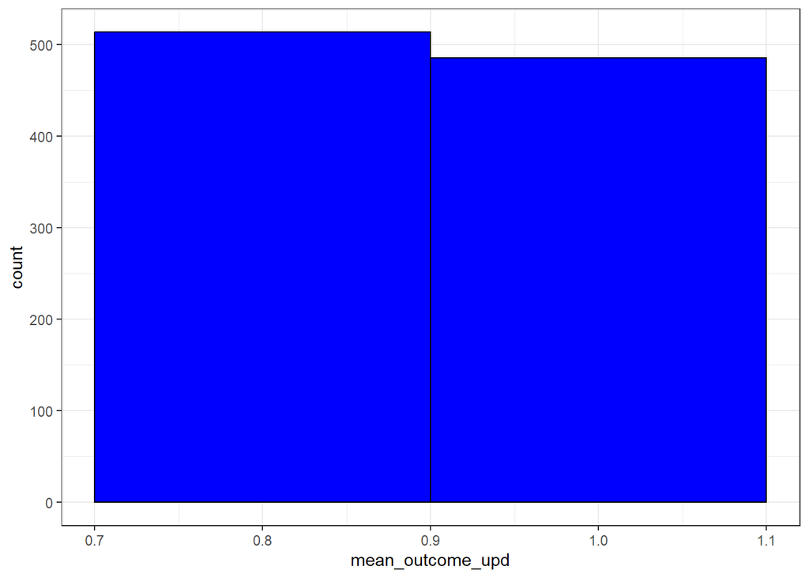

```r
df_sample_mean <- df_all_repeats %>%
  group_by(n_exp) %>%
  dplyr::summarise(mean_outcome_upd = mean(outcome_upd)) %>%
  ungroup()

ggplot(df_sample_mean, aes(x = mean_outcome_upd)) +
  geom_histogram(color = 'black', fill = 'blue', binwidth = 0.2) +
  theme_bw()
```

## Количественные и качественные итоги

```r
error <- sqrt( mean((df_sample_mean$mean_outcome_upd-true_mean)^2) )
print(error)
```

```
## [1] 0.009385734
```

# Зависимость стадартной ошибки среднего от размера выборки

```r
PrP <- read_excel("PrP.xlsx")
```

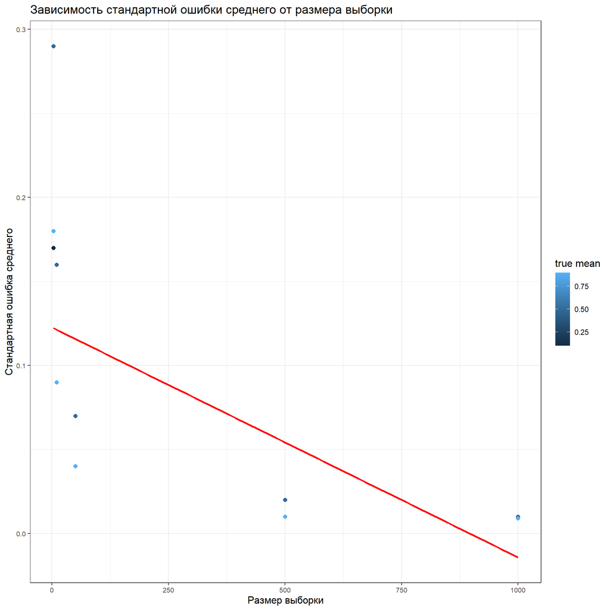

```r
PrP[15, "error"] <- 0.009 #опечаталась, пришлось заменить значение
View(PrP)

ggplot(PrP, aes(x = `sample size`, y = `error`)) +
  geom_point(aes(colour = `true mean`), size = 2) +
  geom_smooth(method = "lm", se = FALSE, colour = "red") +
  labs(
    title = "Зависимость стандартной ошибки среднего от размера выборки",
    x = "Размер выборки",
    y = "Стандартная ошибка среднего"
  ) +
   theme_bw() +
  theme(
    title = element_text(size = 12),
    axis.text.x = element_text(size = 8),
    axis.text.y = element_text(size = 8)
  )
```

# Зависимость стандартной ошибки среднего от значения истинной вероятности события

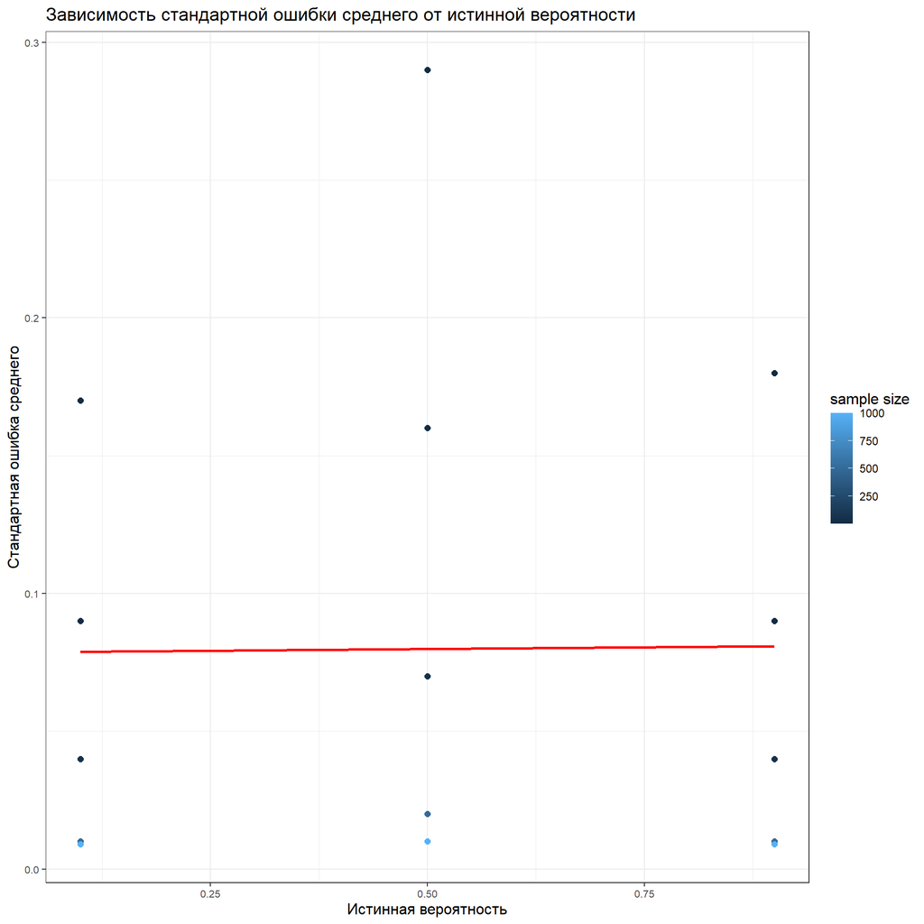

```r
ggplot(PrP, aes(x = `true mean`, y = `error`)) +
  geom_point(aes(colour = `sample size`), size = 2) +
  geom_smooth(method = "lm", se = FALSE, colour = "red") +
  labs(
    title = "Зависимость стандартной ошибки среднего от истинной вероятности",
    x = "Истинная вероятность",
    y = "Стандартная ошибка среднего"
  ) +
   theme_bw() +
  theme(
    title = element_text(size = 12),
    axis.text.x = element_text(size = 8),
    axis.text.y = element_text(size = 8)
  )
```

# Визуализация трех параметров

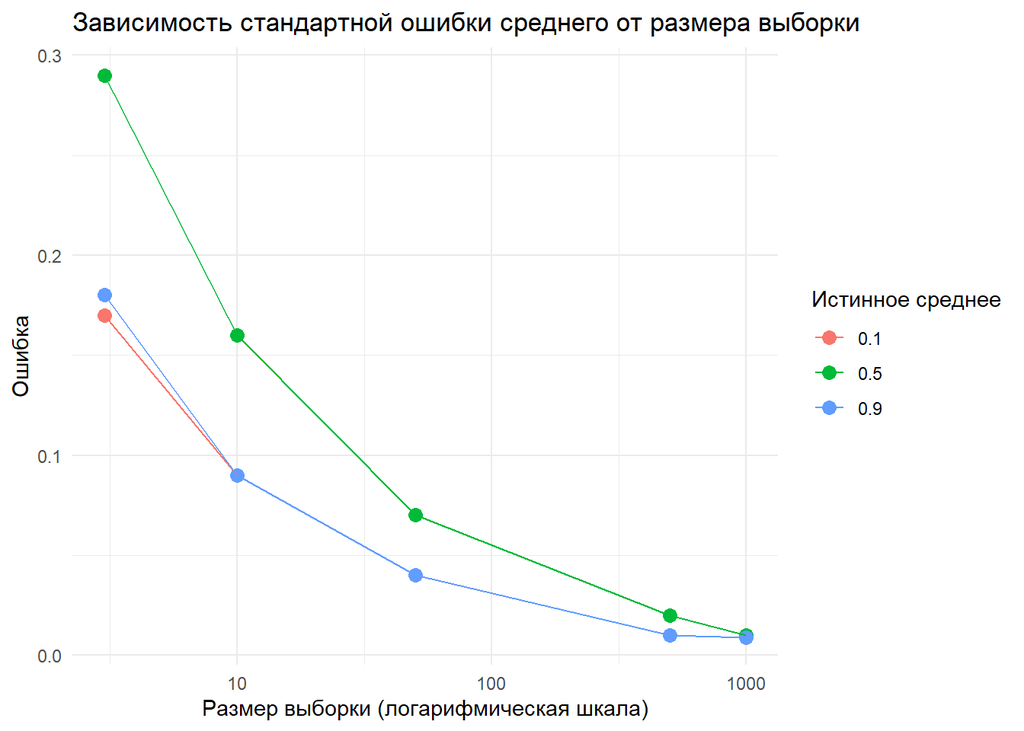

```r
ggplot(PrP, aes(x = `sample size`, y = `error`, color = factor(`true mean`))) +
  geom_point(size = 3) +
  geom_line() +
  scale_x_log10() +
  labs(title = "Зависимость стандартной ошибки среднего от размера выборки",
       x = "Размер выборки (логарифмическая шкала)",
       y = "Ошибка",
       color = "Истинное среднее") +
  theme_minimal()
```

# Выводы:

# Чем больше размер выборки, тем меньше величина ошибки # Наиболее драматичное снижение ошибки - когда переходим от очень малых выборок к средним (хоты бы 10). Для больших выборок совсем маленькое значение ошибки # для значений истинной вероятности 0.5 значение ошибки больше, чем для крайних значений (низкой и высокой вероятности успеха). Это связано с более высокой дисперсией вследствие неопределенности (значение может быть успехом и неудачей с равной вероятностью) #таким образом, с ростом выборки выборочное среднее стремится к истинному значению ГС